# midterm_540

cayden dunn

2022-10-19

```r
library(caret)
wine <- read.csv("/Users/cindydunn/Desktop/Grad_School/math540/midterm/data/wine.csv")
source("/Users/cindydunn/Desktop/Grad_School/math540/logistic_regression/myfunctions copy.r")
```

# type of problem

this is a supervised classifciation problem. as we have examples of labeled data and that data is divided into two classes red and white wine. therefore i will be creating a logistic regression model.

```r
RNGkind (sample.kind = "Rounding")
set.seed(0)
p <- partition.2(wine, 0.7)
training.data <- p$data.train
test.data <- p$data.test

logistic.model <- glm(Type~.,family=binomial(link='logit'),data=training.data)
```

## Perform variable selection using a method of your choice.

going to start with backwards stepwise and see how that works. It seems that backwards step worked rather well it got rid of several predictors.

```r
#backwards stepwise
step.model <- step(logistic.model)
```

```
## Start:  AIC=192.33
## Type ~ fixed.acidity + volatile.acidity + citric.acid + residual.sugar +
##     chlorides + free.sulfur.dioxide + total.sulfur.dioxide +
##     density + pH + sulphates + alcohol + quality
```

```
##                        Df Deviance    AIC
## - sulphates             1   166.62 190.62
## - quality               1   167.47 191.46
## - citric.acid           1   168.24 192.24
## <none>                      166.33 192.33
## - chlorides             1   171.36 195.36
## - volatile.acidity      1   181.08 205.08
## - fixed.acidity         1   185.18 209.18
## - pH                    1   185.74 209.74
## - free.sulfur.dioxide   1   187.02 211.02
## - alcohol               1   250.01 274.01
## - residual.sugar        1   261.58 285.58
## - total.sulfur.dioxide  1   274.67 298.67
## - density               1   293.88 317.88
##
## Step:  AIC=190.62
## Type ~ fixed.acidity + volatile.acidity + citric.acid + residual.sugar +
##     chlorides + free.sulfur.dioxide + total.sulfur.dioxide +
##     density + pH + alcohol + quality
##
##                        Df Deviance    AIC
## - quality               1   167.60 189.60
## - citric.acid           1   168.31 190.31
## <none>                      166.62 190.62
## - chlorides             1   171.52 193.52
## - volatile.acidity      1   182.77 204.77
## - fixed.acidity         1   185.56 207.56
## - pH                    1   185.88 207.88
## - free.sulfur.dioxide   1   187.45 209.45
## - total.sulfur.dioxide  1   275.93 297.93
## - alcohol               1   277.67 299.67
## - residual.sugar        1   292.83 314.83
## - density               1   355.28 377.28
##
## Step:  AIC=189.6
## Type ~ fixed.acidity + volatile.acidity + citric.acid + residual.sugar +
##     chlorides + free.sulfur.dioxide + total.sulfur.dioxide +
##     density + pH + alcohol
##
##                        Df Deviance    AIC
```

[output cut: 13 more lines]

```
## Type ~ fixed.acidity + volatile.acidity + residual.sugar + chlorides +
##     free.sulfur.dioxide + total.sulfur.dioxide + density + pH +
##     alcohol
##
##                        Df Deviance    AIC
## <none>                      169.32 189.32
## - chlorides             1   173.58 191.58
## - pH                    1   186.80 204.80
## - fixed.acidity         1   193.63 211.63
## - free.sulfur.dioxide   1   194.03 212.03
## - volatile.acidity      1   197.87 215.87
## - residual.sugar        1   295.61 313.61
## - alcohol               1   298.47 316.47
## - total.sulfur.dioxide  1   303.35 321.35
## - density               1   355.47 373.47
```

```r
summary(step.model)
```

```
##
## Call:
## glm(formula = Type ~ fixed.acidity + volatile.acidity + residual.sugar +
##     chlorides + free.sulfur.dioxide + total.sulfur.dioxide +
##     density + pH + alcohol, family = binomial(link = "logit"),
##     data = training.data)
##
## Deviance Residuals:
##     Min       1Q   Median       3Q      Max
## -3.6252  -0.0223  -0.0004   0.0480   2.8331
##
## Coefficients:
##                        Estimate Std. Error z value Pr(>|z|)
## (Intercept)           3.075e+03  3.445e+02   8.927  < 2e-16 ***
## fixed.acidity         1.681e+00  3.499e-01   4.804 1.56e-06 ***
## volatile.acidity     -7.687e+00  1.557e+00  -4.936 7.97e-07 ***
## residual.sugar        1.065e+00  1.348e-01   7.897 2.86e-15 ***
## chlorides            -1.266e+01  5.367e+00  -2.360   0.0183 *
## free.sulfur.dioxide  -1.071e-01  2.220e-02  -4.823 1.41e-06 ***
## total.sulfur.dioxide  6.732e-02  8.743e-03   7.700 1.36e-14 ***
## density              -3.098e+03  3.495e+02  -8.867  < 2e-16 ***
## pH                    8.881e+00  2.181e+00   4.072 4.65e-05 ***
## alcohol              -3.622e+00  4.848e-01  -7.470 7.99e-14 ***
## ---
## Signif. codes:  0 '***' 0.001 '**' 0.01 '*' 0.05 '.' 0.1 ' ' 1
##
## (Dispersion parameter for binomial family taken to be 1)
##
##     Null deviance: 3004.92  on 2168  degrees of freedom
## Residual deviance:  169.32  on 2159  degrees of freedom
## AIC: 189.32
##
## Number of Fisher Scoring iterations: 9
```

## Clearly show the steps of model building and report the main results of your analysis (including model evaluation) in a short paragraph.

```r
library(caret)
pred.prob.test <- predict(step.model, newdata = test.data, type = "response")
pred.y.test <- ifelse(pred.prob.test > 0.5, 1, 0)
confusionMatrix(as.factor(pred.y.test), as.factor(test.data$Type), positive = "1")
```

```
## Confusion Matrix and Statistics
##
##           Reference
## Prediction   0   1
##          0 479   2
##          1   3 445
##
##                Accuracy : 0.9946
##                  95% CI : (0.9875, 0.9983)
##     No Information Rate : 0.5188
##     P-Value [Acc > NIR] : <2e-16
##
##                   Kappa : 0.9892
##
##  Mcnemar's Test P-Value : 1
##
##             Sensitivity : 0.9955
##             Specificity : 0.9938
##          Pos Pred Value : 0.9933
##          Neg Pred Value : 0.9958
##              Prevalence : 0.4812
##          Detection Rate : 0.4790
##    Detection Prevalence : 0.4822
##       Balanced Accuracy : 0.9947
##
##        'Positive' Class : 1
##
```

```r
library(pROC)
r <- roc(test.data$Type, pred.prob.test)
```

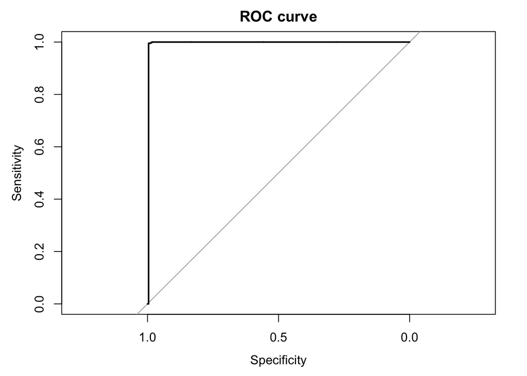

```r
plot.roc(r, main = "ROC curve")
```

```r
auc(r)
```

```
## Area under the curve: 0.9958
```

as we can see from the confusion matrix created on the test data the model preforms very well with a 99% accuracy. the Sensitivity : 0.9955, Specificity : 0.9938 and Kappa : 0.9892 values are also all very high as well so. These metrics as a result of running the model on novel test data means that the model generilzes well for this given data set and is very accurate. Also from the ROC curve graph we can see we have create a model that preformed nearly perfect on the novel test data with the area under the curve being 0.9958